# Workshop 10: Histograms, positions, and facets demo

Joy Vaz

2022-12-12

# 1 Dataset: Childhood diarrheal diseases in Mali

We will visualize distributions of numerical variables in the `malidd` data frame, which we’ve seen in previous lessons.

```r
# Load in and view the `malidd` data frame
malidd <- read.csv(here::here("data/malidd.csv"))
head(malidd)
```

```
##   n admit_date sex age_months height_cm muac_cm breastfeeding vomit fever
## 1 1 2020-01-16   M          5      61.2    11.3             1     0     0
## 2 2 2020-01-17   F         12      70.6    13.2             1     1     1
## 3 3 2020-01-17   M         11      71.1    13.5             1     1     0
## 4 4 2020-01-17   M          9      68.5    12.6             1     0     0
## 5 5 2020-01-21   F         16      78.7    14.2             1     1     0
## 6 6 2020-01-21   M          6      67.7    14.5             1     0     0
##   bloody_stool temp freqrespi viral_load diarrhea_days diarrhea_episodes
## 1            0 35.3        42     0.5727             3                 6
## 2            0 36.7        32     0.7362             4                 5
## 3            0 35.8        60     0.5536             2                 3
## 4            0 35.8        50     0.5536             3                 5
## 5            0 36.4        42     0.7304             0                 3
## 6            0 35.7        52     0.6660             0                 5
##   medication trad_medication       commune mother_education father_education
## 1          0               1    Golobougou                0                0
## 2          1               1 Kalaban-Coura               13                0
## 3          0               0  Kalabancoura               13               16
## 4          0               1 Quartier-Mali                0                0
## 5          0               0        Kabala               13               17
## 6          0               0  Kalabancoura               13               15
##   household_size
## 1             30
## 2              6
## 3             22
## 4             20
## 5              8
## 6              3
```

The dataframe has 21 variables, many of which are continuous, like `height_cm`, `viral_load`, or `temp`.

```r
# Inspect variables
summary(malidd)
```

```
##        n           admit_date            sex              age_months
##  Min.   :  1.00   Length:150         Length:150         Min.   : 0.00
##  1st Qu.: 38.25   Class :character   Class :character   1st Qu.: 6.00
##  Median : 75.50   Mode  :character   Mode  :character   Median : 9.00
##  Mean   : 75.50                                         Mean   :11.31
##  3rd Qu.:112.75                                         3rd Qu.:15.00
##  Max.   :150.00                                         Max.   :48.00
##    height_cm         muac_cm      breastfeeding      vomit
##  Min.   : 50.30   Min.   : 9.30   Min.   :0.00   Min.   :0.0000
##  1st Qu.: 64.50   1st Qu.:12.60   1st Qu.:1.00   1st Qu.:0.0000
##  Median : 70.60   Median :13.50   Median :1.00   Median :0.0000
##  Mean   : 71.20   Mean   :13.36   Mean   :0.84   Mean   :0.3467
##  3rd Qu.: 77.33   3rd Qu.:14.30   3rd Qu.:1.00   3rd Qu.:1.0000
##  Max.   :103.40   Max.   :16.20   Max.   :1.00   Max.   :1.0000
##      fever         bloody_stool          temp        freqrespi
##  Min.   :0.0000   Min.   :0.00000   Min.   :34.5   Min.   :24.00
##  1st Qu.:0.0000   1st Qu.:0.00000   1st Qu.:35.7   1st Qu.:29.00
##  Median :1.0000   Median :0.00000   Median :36.2   Median :36.50
##  Mean   :0.6133   Mean   :0.05333   Mean   :36.4   Mean   :38.34
##  3rd Qu.:1.0000   3rd Qu.:0.00000   3rd Qu.:36.7   3rd Qu.:47.00
##  Max.   :1.0000   Max.   :1.00000   Max.   :39.3   Max.   :60.00
##    viral_load     diarrhea_days  diarrhea_episodes   medication
##  Min.   :0.0458   Min.   :0.00   Min.   : 3.00     Min.   :0.0000
##  1st Qu.:0.3939   1st Qu.:2.00   1st Qu.: 4.00     1st Qu.:0.0000
##  Median :0.5330   Median :3.00   Median : 5.00     Median :0.0000
##  Mean   :0.5050   Mean   :2.92   Mean   : 5.52     Mean   :0.2133
##  3rd Qu.:0.6679   3rd Qu.:4.00   3rd Qu.: 7.00     3rd Qu.:0.0000
##  Max.   :0.8129   Max.   :7.00   Max.   :12.00     Max.   :1.0000
##  trad_medication   commune          mother_education father_education
##  Min.   :0.00    Length:150         Min.   : 0.00    Min.   : 0.000
##  1st Qu.:0.00    Class :character   1st Qu.: 0.00    1st Qu.: 0.000
##  Median :0.00    Mode  :character   Median : 4.50    Median : 5.500
##  Mean   :0.48                       Mean   : 5.14    Mean   : 6.113
##  3rd Qu.:1.00                       3rd Qu.:10.00    3rd Qu.:12.000
##  Max.   :1.00                       Max.   :16.00    Max.   :18.000
##  household_size
##  Min.   : 3.00
##  1st Qu.: 5.25
##  Median :10.00
##  Mean   :12.63
##  3rd Qu.:16.00
##  Max.   :51.00
```

# 2 Basic histograms with `geom_histogram()`

Now let’s use {ggplot2} to plot the distribution of height.

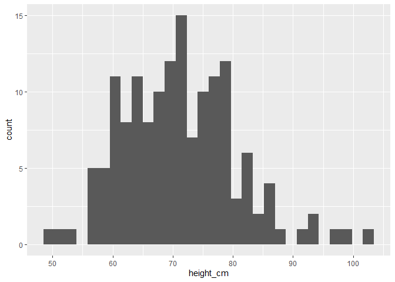

```r
# Simple histogram showing the distribution of height_cm
ggplot(data =  malidd ,
       mapping = aes(x = height_cm)) +
  geom_histogram()
```

It’s hard to get a sense for which range of heights is spanned by each bin in the previous plot, since everything is one big amorphous blob. So let’s add borders around the bins:

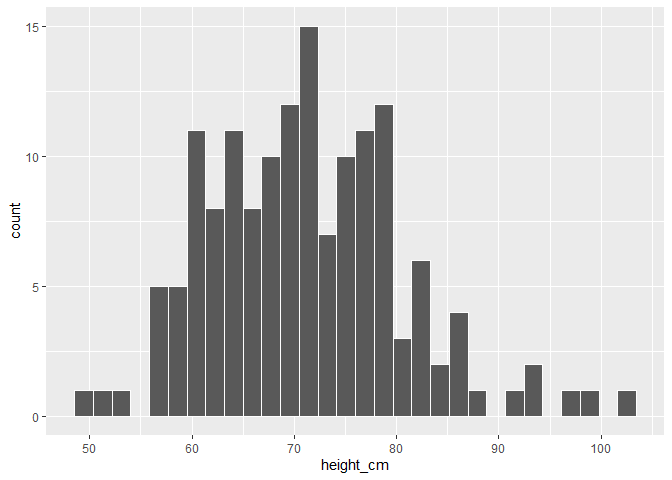

```r
# Set border color to "white"
ggplot(data =  malidd ,
       mapping = aes(x = height_cm)) +
  geom_histogram(color = "white")
```

We now have an easier time associating bin ranges to each of the bars.

# 3 Comparing distributions

We can compare multiple distributions on the same axes.

For example, mapping a categorical variable to the **`fill`** aesthetic will create **stacked** bars.

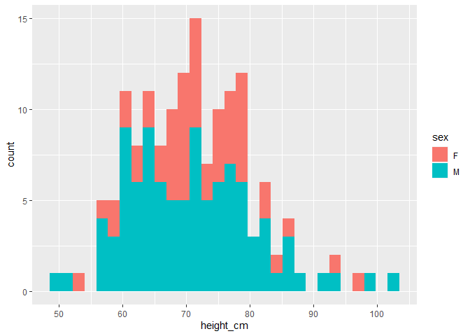

```r
# Map fill to sex
ggplot(data =  malidd ,
       mapping = aes(x = height_cm,
                     fill = sex)) +
  geom_histogram()
```

## 3.1 Position adjustments

You can change the position adjustment within `geom_histogram()`.

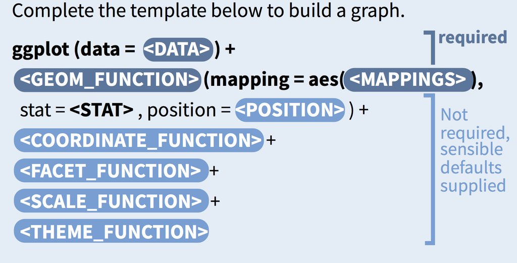

Possible values for the argument **position** in `geom_histogram()` are **`“stack”`**, **`“identity”`**, and **`“dodge”`**.

The default value is `“stack”`, so adding `position = "stack"` will give the same plot.

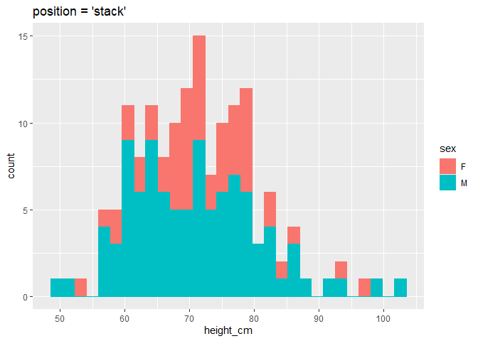

```r
# stack: stacked distributions of a categorical variable
ggplot(data =  malidd ,
       mapping = aes(x = height_cm,
                     fill = sex,
                     color = sex)) +
  geom_histogram(position = "stack") +
  labs(title = "position = 'stack'")
```

Setting `position = 'identity'` causes the bars to **overlap**. To see that overlapping, we need to add make the bars slightly transparent by decreasing opacity (`alpha`).

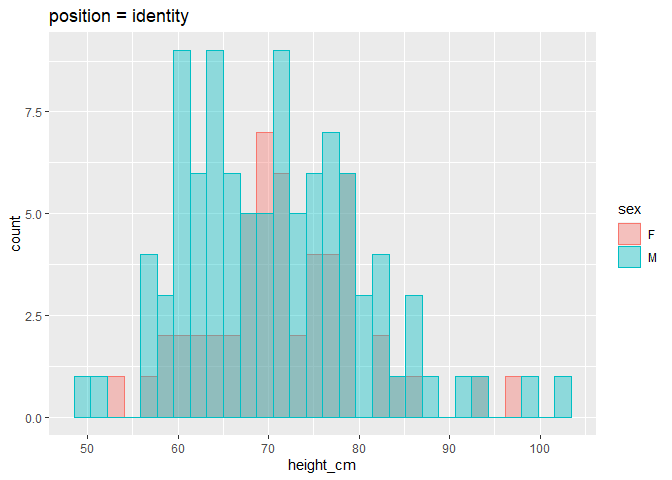

```r
# identity: draw overlapping distributions on the same plot
ggplot(data =  malidd ,
       mapping = aes(x = height_cm,
                     fill = sex,
                     color = sex)) +
  geom_histogram(alpha = 0.4,
                 position = "identity") +
  labs(title = "position = identity")
```

Setting `position = "dodge"` places overlapping bars **directly beside one another**. This makes it easier to compare values.

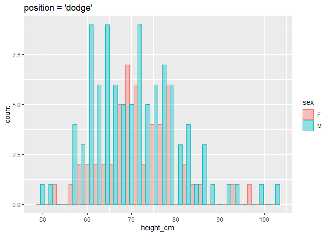

```r
# dodge: interweave distributions on the same plot
ggplot(data =  malidd ,
       mapping = aes(x = height_cm,
                     fill = sex,
                     color = sex)) +
  geom_histogram(alpha = 0.4,
                 position = "dodge") +
  labs(title = "position = 'dodge'")
```

## 3.2 Faceting plots

Another way to add additional variables is to split your plot into **facets**.

When we **facet** a graphs, it gets split up into **multiple panels**, one for each level of a categorical variable.

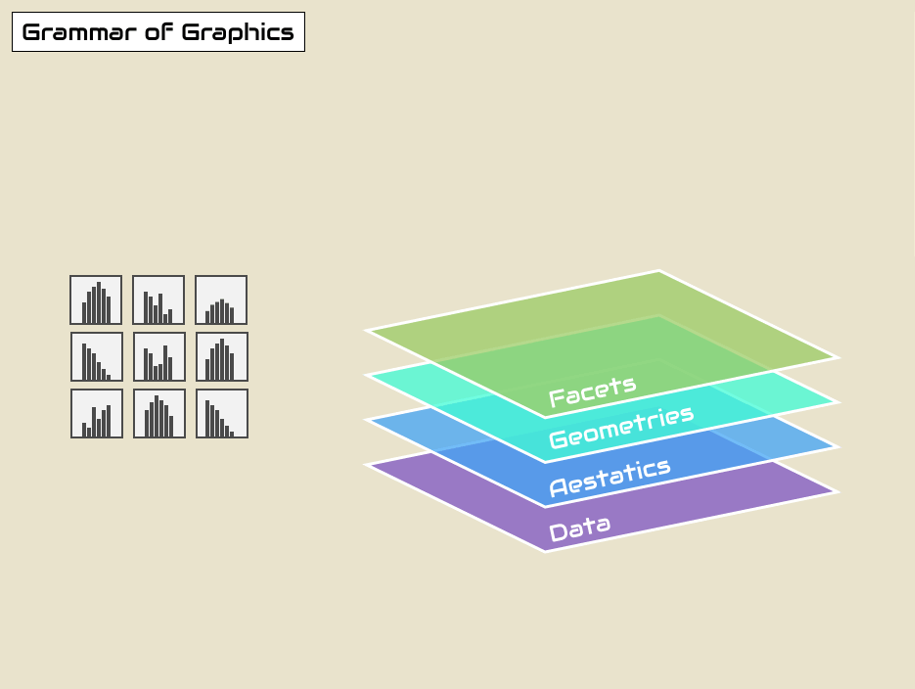

Faceting creates small multiples of a plot, where each panel contains a subset of the data.

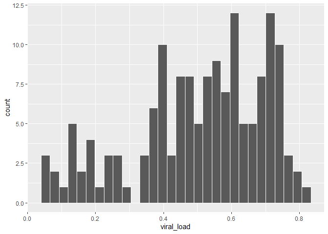

```r
# Base plot
ggplot(data = malidd,
       mapping = aes(x= viral_load))+
    geom_histogram(color="white")
```

### 3.2.1 Facet wrap

To facet your plot by a single variable, use `facet_wrap()`. The first argument of `facet_wrap()` should be a formula, which you create with `~` followed by a variable name. The variable that you pass to `facet_wrap()` should be discrete.

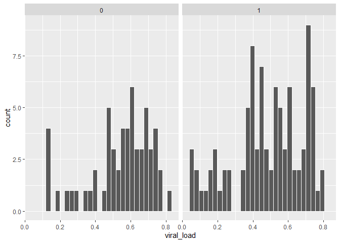

```r
# Facet by fever
ggplot(data = malidd,
       mapping = aes(x= viral_load))+
    geom_histogram(color="white")+
    facet_wrap(~fever)
```

Facets are labelled by the difference values of your categorical variable, (e.g., 1 and 0) and not by the variable name itself (e.g., fever).

Facet labels can be modified using the `labeller` argument. Setting it to `label_both` will give both the variable name and the value.

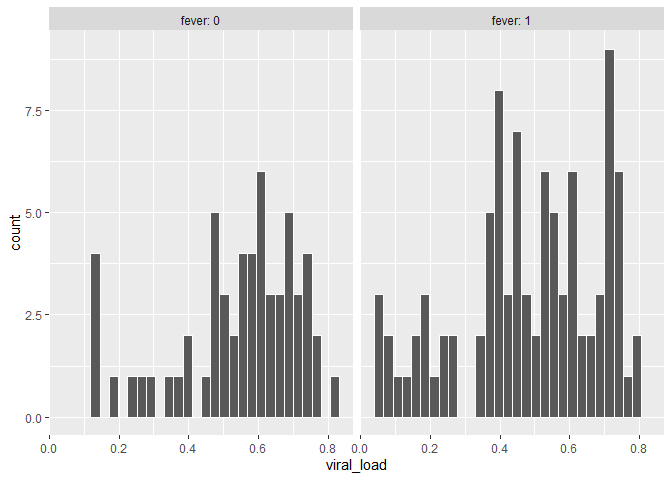

```r
# Add more informative panel labels
ggplot(data = malidd,
       mapping = aes(x= viral_load)) +
    geom_histogram(color="white") +
    facet_wrap(~fever,
               labeller = label_both)
```

### 3.2.2 Facet grid

To facet your plot on the combination of two variables, we use `facet_grid()`. This time the formula should contain two variable names separated by a `~`.

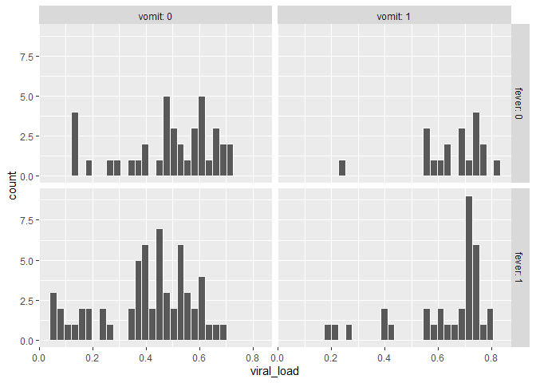

```r
# Facet by fever and vomiting
ggplot(data = malidd,
       mapping = aes(x= viral_load)) +
    geom_histogram(color="white") +
    facet_grid(fever ~ vomit,
               labeller = label_both)
```